# SarahGDataGraphicRedone

Sarah Gillespie

4/3/2019

###### My process:

###### I took the invitation to recreate an data graphic from [an article redesigning past Economist graphs](https://medium.economist.com/mistakes-weve-drawn-a-few-8cdd8a42d368). This data graphic goes with a March 2017 article titled [“Science remains male-dominated”](https://www.economist.com/science-and-technology/2017/03/11/science-remains-male-dominated).

###### I copied the data into Google Sheets, removed the top row, and relabeled the columns to not have spaces and to be more accurate to their data. Then I downloaded the file as a CSV and uploaded it into Rstudio.

###### The article focuses on the overall publication and patent proportion by country (rather than in-depth analysis by field on the orginal graphic), so I thought my ggplot graphic should have a similar focus. I found the average of percent of publications by women across all fields, weighing each field equally. This might not be ideal statistics but it was the best I could do with the limited data. I kept the inventor proportion the same because filing a patent has a different process and requirements than publishing a reseach paper in academia.

###### I created a data frame using dyplr functions and reshape2’s melt, then made a grouped bar plot using ggplot2 and ggthemes.

###### One problem with this data graphic is the order of the countries. I wish they were in descending order starting with the country with the highest proportion of women producing STEM reseach papers, but instead it is in reverse alphabetical order by country.

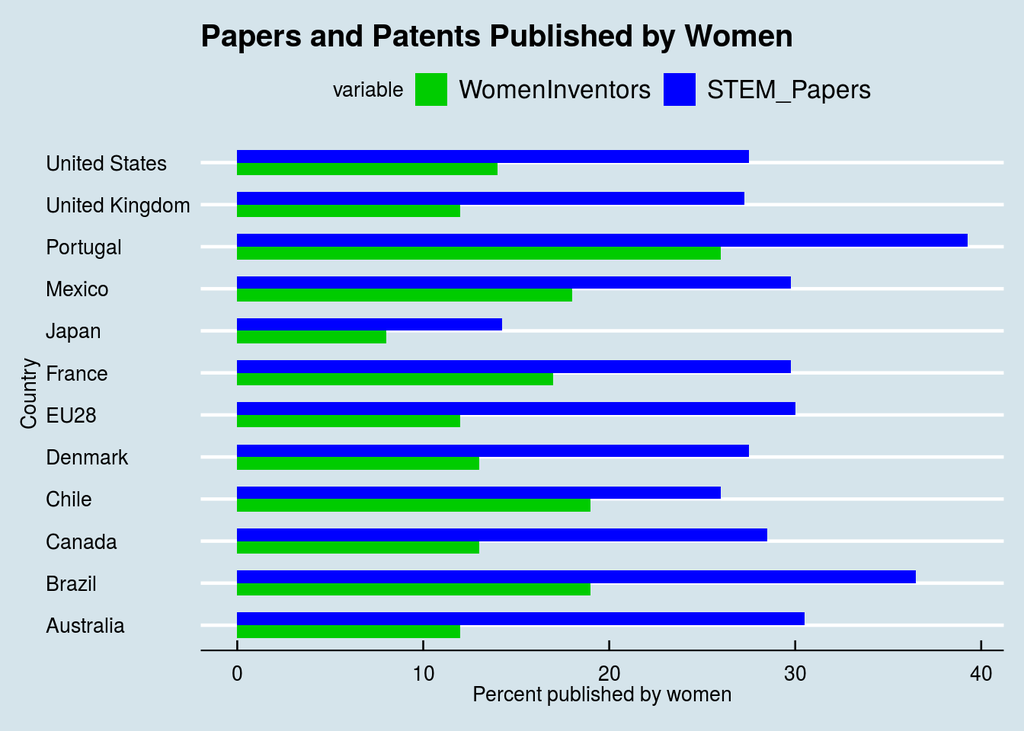

###### Notes on data:

###### Papers published Indexed in Scopus

###### Inventors Who filed patent applications

###### Sources: “Gender in the Global Research Landscape” by Elsevier; *The Economist*

[^1]

[^1]: [Github Repository](https://github.com/SarahGillespie/EconomistGraphicRedone)